# 1_Practical

Ryan Greenup 17805315

12 March 2019

# Logistic Regression

Material of Tue 26 2019, week 4

It’s worth bearing in mind that Logistic regression is basically the same as linear regression for an output value that is categorical, i.e. if linear assumptions hold and $Y \in \mathbb{Z} \wedge Y = f(X) + \varepsilon \implies f = \sum^n_{i=1} \left[a_i \cdot \frac{e^{\alpha + \beta x_i}}{1+e^{\alpha + \beta x_i}} \right]$.

This is a parametric method because all we need to do now is solve parameter coefficients. This is supervised learning because there are output values.

## Question 01: Logistic Regression: Use “Default” data sets

### 1. Start R studio. Upload “Default” data set built in R and View the data sets using the Console.

```r
def <- read.csv(file = "Datasets/Default.csv")

head(def)
```

```
##   X default student   balance    income
## 1 1      No      No  729.5265 44361.625
## 2 2      No     Yes  817.1804 12106.135
## 3 3      No      No 1073.5492 31767.139
## 4 4      No      No  529.2506 35704.494
## 5 5      No      No  785.6559 38463.496
## 6 6      No     Yes  919.5885  7491.559
```

```r
    # writeLines("\n")
    # print("***Dimensions***")
    writeLines("\n")
```

```r
dim(def)
```

```
## [1] 10000     5
```

```r
    # writeLines("\n")
    # print("***Summary***")
    # writeLines("\n")
summary(def)
```

```
##        X         default    student       balance           income
##  Min.   :    1   No :9667   No :7056   Min.   :   0.0   Min.   :  772
##  1st Qu.: 2501   Yes: 333   Yes:2944   1st Qu.: 481.7   1st Qu.:21340
##  Median : 5000                         Median : 823.6   Median :34553
##  Mean   : 5000                         Mean   : 835.4   Mean   :33517
##  3rd Qu.: 7500                         3rd Qu.:1166.3   3rd Qu.:43808
##  Max.   :10000                         Max.   :2654.3   Max.   :73554
```

```r
    # writeLines("\n")
    # print("***Structure***")
    # writeLines("\n")
str(def)
```

```
## 'data.frame':    10000 obs. of  5 variables:
##  $ X      : int  1 2 3 4 5 6 7 8 9 10 ...
##  $ default: Factor w/ 2 levels "No","Yes": 1 1 1 1 1 1 1 1 1 1 ...
##  $ student: Factor w/ 2 levels "No","Yes": 1 2 1 1 1 2 1 2 1 1 ...
##  $ balance: num  730 817 1074 529 786 ...
##  $ income : num  44362 12106 31767 35704 38463 ...
```

```r
    # writeLines("\n")
```

#### Dummy Variables

when `glm` is used on a categorical variable that is stored as the `factor` class in *R* the categorical variables will be encoded as dummy variables (i.e. they will become numbers that are stored as `factors` ), I thought it might be better to do this yourself because otherwise you have to figure out which dummy variable corresponds to what, however at p. 157 of the textook a different approach is taken; `glm` was used and then `contrasts(def$student)` was used to work out which was what, that’s probably the better way to do it.

You shouldn’t work with dummy variables at all, that’s what contrasts are for, work with contrasts[^1] instead[^2] of doing it all by hand, it will prevent you from making a mistake.

If values are already numeric but represent categorical variables, it is necessary to ensure that they are of the `factor` class not `numeric`/`integer`/`double` etc. because otherwise the model will perform sub-optimally. This can be tested by using `class()`.[^3]

If values are integers but need to be considered as discrete values, it is usually better to convert them into `factors` as well, otherwise models will simply assume they are continuous variables and perform suboptimally (it may be worth preserving two colums in a data frame for the factorised and original data, ocassionally plots will complain about discrete data data and it will be easier to feed them the numeric data).

first convert the data from factors to something else just so we can see how to do that, the easiest in this case is a `character` (be mindful in *R* there is no `string` class, instead there is only the `character` class, this is distinct from *C*-like languages such as java), again this can be tested by using `class()`.

There is also `typeof()` which returns the type of the object from the perspective of *R*, `class()` refers to the perspective of an Object-Orientated programming language.

```r
def$default <- as.factor(def$default)
def$student <- as.factor(def$student)
glm(formula = default ~ balance, data = def, family = "binomial")
```

```
##
## Call:  glm(formula = default ~ balance, family = "binomial", data = def)
##
## Coefficients:
## (Intercept)      balance
##  -10.651331     0.005499
##
## Degrees of Freedom: 9999 Total (i.e. Null);  9998 Residual
## Null Deviance:       2921
## Residual Deviance: 1596  AIC: 1600
```

```r
contrasts(def$default)
```

```
##     Yes
## No    0
## Yes   1
```

```r
contrasts(def$student)
```

```
##     Yes
## No    0
## Yes   1
```

### 2. Plot Income verses Balance (i.e. Plot the Predictors against Each other)

Generally it would be more appropriate to map the output variable to the colour, because colour is easier to see than shape and it is the output variable we are most concerned with.

#### GGplot

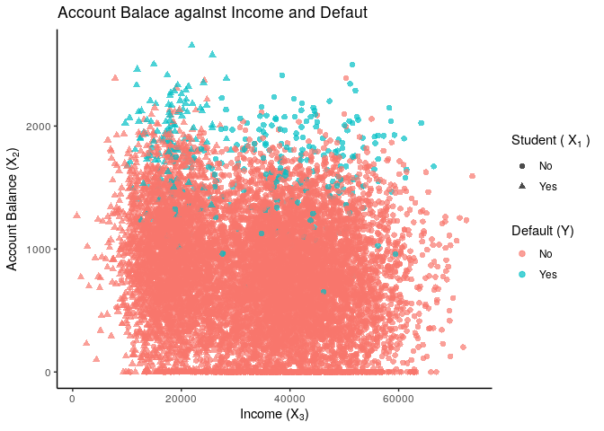

```r
predplot <- ggplot(data = def, aes(y = balance, x = income, col = default, shape = student)) +
  geom_point(size = 2, alpha = 0.7) +
  labs(y = TeX("Account Balance $(X_2)$"), x = TeX("Income ($X_3$)"), shape = TeX("Student ( X_1 )"), col = "Default (Y)",
       title = "Account Balace against Income and Defaut") +
  theme_classic()

predplot
```

```r
#ggplotly(predplot) # This does not support latex!
```

It’s hard to see whether or not there are any defaults in the centre of the plot, hence map the alpha-level to the default and let’s invert this plot so that the split occurs along left/right, that way it will resemble our box plots (this is done simply for want of being able to visualise the data, both the axis are predivitive features so it doesn’t matter):

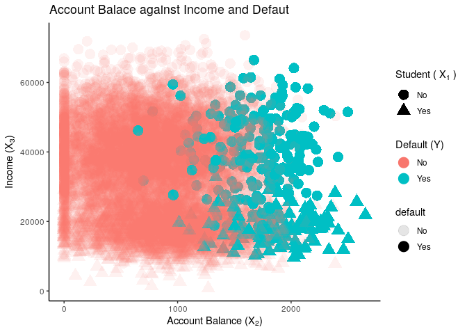

```r
ggplot(data = def, aes(x = balance, y = income, col = default, shape = student)) +
  geom_point(size = 5, aes(alpha = default)) +
  labs(x = TeX("Account Balance $(X_2)$"), y = TeX("Income ($X_3$)"), shape = TeX("Student ( X_1 )"), col = "Default (Y)",
       title = "Account Balace against Income and Defaut") +
  theme_classic()
```

Now it can be clearly seen that defaults occur at a higher frequency when there is a higher account balance, and maybe slightly higher for students than non-students (there;s mayve very slightly less triangles on the right side than left.)

It seems to be totally independent of income.

##### BoxPlot

It is necessary to observe the behaviour of the output variable in response to all the predictors, however it is innapropriate to use a scatterplot because it comes out almost useless:

A boxplot is the correct way to do this,[^4] using the output along the $x$-axis and the predictor along the $y$ axis, we can create two sets of this in ggplot by mapping the `x=student` and `fill = default`.

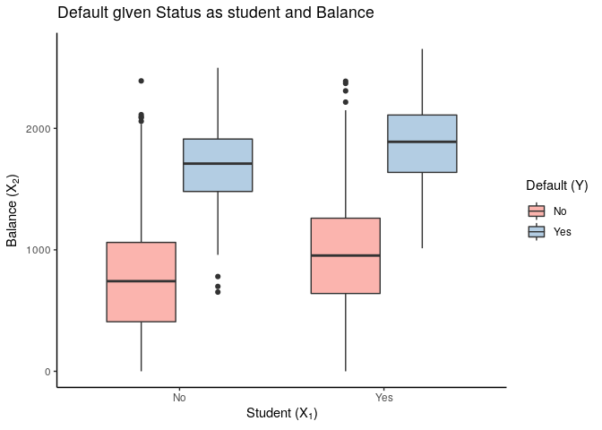

```r
ggplot(data = def, aes(x = student, y = balance, fill = default)) + #The predict
  geom_boxplot() +
  theme_classic() +
  labs(y = TeX("Balance ($X_2$)"), x = TeX("Student ($X_1$)") , fill = TeX("Default ($Y$)"),
       title = TeX("Default given Status as student and Balance")) +
  scale_fill_brewer(palette = "Pastel1")
```

From here it can clearly be seen that there are some outliers for balance but it is a significant predictorv of defaulting, it can also be seen that generally students are more likely to default but this is a non-significant observation.

The textbook chose to visualise the boxplots as below, I think this is undesirable because the interaction of income is already clear from the preceeding plot and because student has a more significant impact than income that should be considered.

[figure not shown]

```r
balplot <- ggplot(data = def, aes(x = default, y = balance, fill = default)) +
  geom_boxplot() +
  labs(x = TeX("Default $(Y)$"), y = TeX("Balance $(X_2)$"), title = "Default given Account Balance") +
  theme_classic2() +
  guides(fill = FALSE) +
  scale_fill_brewer(palette = "Pastel1")


incplot <- ggplot(data = def, aes(x = default, y = income, fill = default)) +
  geom_boxplot() +
  labs(x = TeX("Default $(Y)$"), y = TeX("Balance $(X_33$"), title = "Default given Account Balance") +
  theme_classic2() +
  guides(fill = FALSE) +
  #scale_fill_discrete(direction = 1, h.start = 99, )
  scale_fill_brewer(palette = "Pastel1")

grid.arrange(balplot, incplot, nrow = 1)
```

#### Base Plot

[figure not shown]

```r
plot(income ~ balance, data = def,
    main = "Credit Defaults",
     xlab = "Income",
     ylab ="Balance",
     pch = c(1, 2)[as.numeric(student)],
     col = c("IndianRed", "Royalblue")[as.numeric(default)],
    cex = 0.7)
```

### 3. Construct the Multiple Linear Logistic Model for default in terms of the Predictors balance, student and income.

In order to create a logistic model use the `glm` function which is a *generalised linear model* function, because this is just an exponentiated linear function.

- Choose `family = binomial`
  - categorical variables are not normally distributed because they are not continuous, a binomial distribution is the corresponding distribution for discrete data
- Choose `link = logit`
  - Use `probit` for when the seperation of data is distinct, it performs slightly better.
  - the term *logit* is another word for *log odds*:
    - $\log{\left(\frac{\text{P}\left(X\right)}{1 - \text{P}\left(X\right)}\right)}$

```r
ModDef <- glm(formula = default ~ student + balance + income, family = binomial(link = "logit"), data = def)
contrasts(def$default)
```

```
##     Yes
## No    0
## Yes   1
```

### 4. Show how you would calculate the probability (the default = “yes”) for a given set of X (predictor) values.

In order to find the probability just use the predict command:

#### Create the data frame of new data

Use a data frame rather than a list, that way the format of your input, output and predicted data is all equivalent.

```r
newdata <- data.frame(
#   "student" = as.factor(c("Yes", "Yes", "No", "Yes")), # Normal
      #If I wanted to create random points.
    "student" = ifelse(sample(c(0, 1), size = 4, replace = TRUE)==0, "No", "Yes"),
   "balance" = rnorm(n = 4, 1500, sd = 500),
   "income" = rnorm(n = 4, mean = 50000, sd = 15000)
   )
```

Now call the `predict` command and use `cbind` to combine the `newdata` with the predicted data.

By default the predict command will output the value of the *logit* or the *log-odds*:[^5]

$$\verb|output| = \log\left( \frac{ \text{Pr}\left(X\right) }{1 - \text{Pr}\left(X\right) } \right)$$
Clearly the raw probability would be considerably more useful to us, hence specify the parameter `type="Response"`:

```r
predVals <- predict(object = ModDef, newdata, type = "response")
cbind("default_prob" = predVals, newdata)
```

```
##   default_prob student   balance   income
## 1  0.003597183     Yes  996.0236 58720.54
## 2  0.718389588     Yes 2131.6236 73921.83
## 3  0.106698601     Yes 1611.5783 48155.68
## 4  0.934770901      No 2334.8403 45366.55
```

all the corresponding values can be returned by not specifying the `newdata` parameter in the predict command, it would also be possible to return the `fitted.values` from the model object, the fitted values will represent the probability because it is the natural position along the $y$-axis, it is the fitted value

```r
ModelPreds <- cbind(def, "Probability" = ModDef$fitted.values)

#ModelPreds <- cbind(def, "Probability" = predict(ModDef, type = 'response'))   #This would do the same thing
```

In order to move from the probability to the decision the threshold would have to be specified:

```r
threshold <- 0.5
ModelPreds$prediction <- rep_len(x ="No", length.out = nrow(ModelPreds))
ModelPreds$prediction[ModelPreds$Probability > threshold] <- "Yes"
ModelPreds$prediction <- as.factor(ModelPreds$prediction)
ModelPreds <- ModelPreds[,c(2,6,7,3,4,5)]
head(ModelPreds)
```

```
##   default  Probability prediction student   balance    income
## 1      No 0.0014287239         No      No  729.5265 44361.625
## 2      No 0.0011222039         No     Yes  817.1804 12106.135
## 3      No 0.0098122716         No      No 1073.5492 31767.139
## 4      No 0.0004415893         No      No  529.2506 35704.494
## 5      No 0.0019355062         No      No  785.6559 38463.496
## 6      No 0.0019895182         No     Yes  919.5885  7491.559
```

```r
#Alternative approach
#threshold <- 0.5
#Predictions <- ifelse(ModelPreds$Probability < threshold, 0, 1)
#ModelPreds <- cbind(ModelPreds, "Prediction" = Predictions)
```

### 5. Construct the Misclassification Martrix

The misclassification matrix (or confusion matrix) is a matrix for the False and True Positives, it can be a good idea to wrap this in a function because later on it may be necessary to use a loop to return a ROC curve.

#### Construct functions to Compute FPR and TPR

##### base

This is the method that oliver taught us

[output not shown]

This is a more elegent strategy using `table(predictions, observations)`, the order should be specified as such by convention I have seen in the TB and [online](https://www.datacamp.com/community/tutorials/confusion-matrix-calculation-r), this way also matches the `confusionMatrix()` functoin inside the `caret` package

By convention the rows will represent the predicted values and the columns will represent the observed values. . however one page of the textbook shows it in print the otherway but generates in code this way so that’s a little confusing.

```r
conf.mat <- table(ModelPreds$prediction, ModelPreds$default, dnn = c("Predicted", "Observed"))
print(conf.mat)
```

```
##          Observed
## Predicted   No  Yes
##       No  9627  228
##       Yes   40  105
```

```r
# It can be a little difficult to determine which one is the prediction using table
  #if you don't get the order of prediction then observation right, so
    # you can also use `confusionMatrix` from the `caret` package to triple check.


conf.mat2 <- confusionMatrix(ModelPreds$prediction, ModelPreds$default)
print(conf.mat2)
```

```
## Confusion Matrix and Statistics
##
##           Reference
## Prediction   No  Yes
##        No  9627  228
##        Yes   40  105
##
##                Accuracy : 0.9732
##                  95% CI : (0.9698, 0.9763)
##     No Information Rate : 0.9667
##     P-Value [Acc > NIR] : 0.0001044
##
##                   Kappa : 0.4278
##
##  Mcnemar's Test P-Value : < 2.2e-16
##
##             Sensitivity : 0.9959
##             Specificity : 0.3153
##          Pos Pred Value : 0.9769
##          Neg Pred Value : 0.7241
##              Prevalence : 0.9667
##          Detection Rate : 0.9627
##    Detection Prevalence : 0.9855
##       Balanced Accuracy : 0.6556
##
##        'Positive' Class : No
##
```

### 6. Calculate the Prob (Misclassification) or Misclassification Rate

In order to determine the missclassification rate we would, in this case the diagonals are the correct predictions and the off-diagonals are misclassifications

```r
misclass <- (40+228)/(9627+228+40+105)

print(paste("The misclassification rate is: ", percent(misclass)))
```

```
## [1] "The misclassification rate is:  2.68%"
```

in practice we would just take the mean value of the missclassifications, because under the hood true and false correspond to 1/0 in R.

```r
misclass <- mean(ModelPreds$default != ModelPreds$prediction)
print(paste("The misclassification rate is: ", percent(misclass)))
```

```
## [1] "The misclassification rate is:  2.68%"
```

### 7. Calculate the FPR and FNR

Incorrect will be off-diagonals.

The False positive rate will be the number of times that the prediction is positive but the observation is negative, so the second row, first column of the confusion matrix.

The False Negative rate will be the number of times that the prediction is negative but the observation is positive, so first row second column:

```r
conf.mat
```

```
##          Observed
## Predicted   No  Yes
##       No  9627  228
##       Yes   40  105
```

```r
FPR <- conf.mat[2,1] / nrow(ModelPreds)
FNR <- conf.mat[1,2] / nrow(ModelPreds)
```

The false positive rate is 0.004 and the False Negative rate is 0.0228

#### Choose the ideal threshold based on the ROC curve

##### Terminology

$$\textit{Sensitivity} \text{ is } \textbf{TruePosRate}\\
\textit{Specificity} \text{ is } \textbf{TrueNegRate}$$

First Create a tpr function:

```r
tpr <- function(model, observation, threshold, silent){
   probability <- model$fitted.values

  prediction <- rep_len(x ="No", length.out = length(observation))
  prediction[probability > threshold] <- "Yes"
  prediction <- as.factor(prediction)

   conf.mat <- table(prediction, observation, dnn = c("Predicted", "Observed"))
    conf.mat2 <- confusionMatrix(prediction, observation)
    if (!silent) {
    print(conf.mat2)
    }

     tpr <- conf.mat2[["byClass"]][["Sensitivity"]]
#   tpr <- 1- conf.mat[2,2]/(conf.mat[2,2] + conf.mat[1,1])
    fnr <- 1-conf.mat2[["byClass"]][["Specificity"]]

    return(c(tpr, fnr))

}

tpr(ModDef, def$default, threshold = 0.5, silent = FALSE)
```

```
## Confusion Matrix and Statistics
##
##           Reference
## Prediction   No  Yes
##        No  9627  228
##        Yes   40  105
##
##                Accuracy : 0.9732
##                  95% CI : (0.9698, 0.9763)
##     No Information Rate : 0.9667
##     P-Value [Acc > NIR] : 0.0001044
##
##                   Kappa : 0.4278
##
##  Mcnemar's Test P-Value : < 2.2e-16
##
##             Sensitivity : 0.9959
##             Specificity : 0.3153
##          Pos Pred Value : 0.9769
##          Neg Pred Value : 0.7241
##              Prevalence : 0.9667
##          Detection Rate : 0.9627
##    Detection Prevalence : 0.9855
##       Balanced Accuracy : 0.6556
##
##        'Positive' Class : No
##
```

```
## [1] 0.9958622 0.6846847
```

## Question 02: Logistic Regression: Use “Smarket” data set.

### 1. Start R studio. Upload “Smarket” data set built in R and View the data sets using the Console.

```r
head(Smarket)
```

```
##   Year   Lag1   Lag2   Lag3   Lag4   Lag5 Volume  Today Direction
## 1 2001  0.381 -0.192 -2.624 -1.055  5.010 1.1913  0.959        Up
## 2 2001  0.959  0.381 -0.192 -2.624 -1.055 1.2965  1.032        Up
## 3 2001  1.032  0.959  0.381 -0.192 -2.624 1.4112 -0.623      Down
## 4 2001 -0.623  1.032  0.959  0.381 -0.192 1.2760  0.614        Up
## 5 2001  0.614 -0.623  1.032  0.959  0.381 1.2057  0.213        Up
## 6 2001  0.213  0.614 -0.623  1.032  0.959 1.3491  1.392        Up
```

### 2. Construct the Multiple Linear Logistic Model for Direction in terms of the Predictors Lag1, Lag2, Lag3, Lag4, Lag5 and Volume.

```r
#Check that it's a factor
class(Smarket$Direction)
```

```
## [1] "factor"
```

```r
#Make it a factor
Smarket$Direction <- as.factor(Smarket$Direction)

LogModSmarket <- glm(formula = Direction ~ Lag1 + Lag2 + Lag3 + Lag4 + Lag5 + Volume, data = Smarket, family = binomial(link = "logit"))
```

### 3. Show how you would calculate the probability (the Direction = “up”) for a given set of X (predictor) values.

Generate some newdata

```r
n <- 4
maxval <- max(Smarket$Today)
minval <- min(Smarket$Today)

newdata <- data.frame(
                      Lag1 = sample(seq(from = minval, to = maxval, length.out = 1000), size = n),
                      Lag2 = sample(seq(from = minval, to = maxval, length.out = 1000), size = n),
                      Lag3 = sample(seq(from = minval, to = maxval, length.out = 1000), size = n),
                      Lag4 = sample(seq(from = minval, to = maxval, length.out = 1000), size = n),
                      Lag5 = sample(seq(from = minval, to = maxval, length.out = 1000), size = n),
                      Volume = sample(seq(
                        from = min(Smarket$Volume), to = max(Smarket$Volume), length.out = 1000)
                        , size = n)
                      )
```

Now feed this data into the model:

```r
predicteddata <- predict(object = LogModSmarket, newdata, type = "response")
predicteddata <- data.frame(Probability = predicteddata, newdata )
```

In order to create the predictions use `contrasts` to check how the dummy variables have been assigned.

```r
contrasts(Smarket$Direction)
```

```
##      Up
## Down  0
## Up    1
```

Hence Up is 1 so in order to create the prediction from the probability (assuming an 0.5 threshold):

```r
predicteddata$Predictions <- "Down"
predicteddata$Predictions[predicteddata$Probability > 0.5] <- "Up"

# Don't forget that it needs to be a factor,
  # Because of some really strange behaviour in R this MUST be done last
predicteddata$Predictions <- as.factor( predicteddata$Predictions)
predicteddata <- predicteddata[,c(8, 1:7)]

# If Else could also have been used like this
    #This is neat because it's using if/else across data without a loop
      #Just rember that this returs values, it won't assign them inside like a
      #loop otherwise would

predicteddata$Predictions <- ifelse(predicteddata$Probability > 0.5, "Up", "Down")

predicteddata
```

```
##   Predictions Probability       Lag1       Lag2      Lag3      Lag4
## 1          Up   0.5013020 -0.8583814  3.3012282 3.4932102 -4.335388
## 2          Up   0.5845357 -0.8263844 -0.8477157 4.1331502 -3.492801
## 3        Down   0.4970459 -2.2235866  4.2398068 4.0478248 -3.716780
## 4        Down   0.4439511  0.8587908  3.3332252 0.6134805 -1.988942
##         Lag5    Volume
## 1 -4.6446927 1.9040272
## 2 -0.9117097 2.7129957
## 3 -4.8580060 1.2630105
## 4 -1.6583063 0.9858898
```